# CC Tutorial Functions and Loops

Edwin Yánez

2025-03-14

```r
knitr::opts_chunk$set(echo = TRUE)

library(tidyverse)
library(vroom)
library(gridExtra)
```

## Purpose

This is a follow-along document reporting my engagement with Coding Club’s [Intro to functional programming](https://ourcodingclub.github.io/tutorials/funandloops/index.html) tutorial. Most of the content is lifted directly from there with minor modifications and updates from my part. Not everything in the tutorial should be expected to be replicated here.

The data contains information on tree stems surveyed in four 1 Ha plots at fieldsites around southern Africa. trees_bicuar contains data for trees in Bicuar National Park in southwest Angola, and trees_mlunguya contains data for trees in southern Mozambique. Each tree stem >5 cm trunk diameter was measured for tree height and trunk diameter, and identified to species.

## Building a simple function

```r
trees_bicuar <- vroom::vroom('trees_bicuar.csv')
trees_mlunguya <- vroom::vroom('trees_mlunguya.csv')
```

The basic syntax for creating a function looks like this:

```r
example.fn <- function(x,y){
  # Perform an action using x and y
  x + y
}
example.fn(x = 1, y = 2)
```

```
## [1] 3
```

Note that the convention is to name a function using `.` rather than `_` which is normally used to define data objects. This isn’t a rule, but it’s best to stick to the conventions used by other programmers to keep things consistent.

We can also define a function that calculates the basal area of each stem in m^2 from the diameter, which is in cm. The basal area is the cross-sectional area of the tree trunk if it was cut parallel to the ground.

```r
basal.area <- function(x){
  (pi*(x)^2)/40000
}
```

This function has one input, x. x can be a numeric vector, or a numeric column in a dataframe, basically anything that doesn’t cause an error in the body of the function. The body of the function multiplies x^2 by pi, then divides by 40,000, giving the basal area as an output.

Test the function by supplying the diameter column from the Bicuar tree stem data (trees_bicuar$diam) to see what the output is:

```r
#basal.area(x = trees_bicuar$diam)
```

Function arguments don’t need to be called x and y, they can be any character string, for example, the function below works identically to the one above, only x is now referred to as dbh:

```r
basal.area <- function(dbh){
    (pi*(dbh)^2)/40000
}
```

Additionally, you can add a indeterminate number of extra arguments using the `...` operator. Imagine that we want to extend our `basal.area()` function so that it can compute the combined basal area of multiple vectors of diameter measurements, e.g. from multiple sites:

```r
basal.area <- function(...){
  (pi*c(...)^2)/40000
}
#basal.area(trees_bicuar$diam, trees_mlunguya$diam)
```

Just like a normal function, the output of basal.area() can be assigned to a new object, for example, as a new column in trees_bicuar:

```r
trees_bicuar$ba <- basal.area(dbh = trees_bicuar$diam)
```

Writing functions for simple operations like the example above is useful if you want to perform the same operation multiple times throughout a script and don’t want to copy and paste the same code (e.g. (pi*(dbh)^2)/40000) multiple times, this reduces the chances that you will make a typo when copying and pasting.

## Functions in loops

We’ve seen how to write a function and how they can be used to create concise re-usable operations that can be applied multiple times in a script without having to copy and paste, but where functions really come into their own is when combined with looping procedures. Loops serve to run the same operation on a group of objects, further minimising the replication of code.

Loops come in two main variants in R, `for()` loops and `while()` loops. In this workshop we will focus on `for()` loops, which are generally easier to read than `while()` loops, and can be used to perform the same sorts of actions. `while()` loops are used mainly when the user wants to perform an action a set number of times, whereas a `for()` loop is generally used when the user wants to perform an action on a named set of objects.

A `for()` loop iterates through a number of items, most commonly stored as a list, and performs some action equally on each item. It can drastically reduce the amount of copying and pasting.

The basic syntax for creating a `for()` loop looks like this:

```r
while(FALSE){
  for(i in list){
      # PERFORM SOME ACTION
  }
}
```

Imagine you have multiple field sites, each with four 1 Ha plots with the tree stem measurements described earlier. The data for each fieldsite is contained in a different dataframe, e.g. trees_bicuar and trees_mlunguya. If we wanted to calculate the basal area for all stems at both sites, we could run:

```r
trees_bicuar$ba <- basal.area(trees_bicuar$diam)
trees_mlunguya$ba <- basal.area(trees_mlunguya$diam)
```

The above seems fine for now, but what if we had 100 field sites instead of just two? In that case, you can use a `for()` loop. First, we have to create a list of dataframes to perform the loop on. There are many ways of doing this, but the simplest way is:

```r
trees <- list(`trees_bicuar` = trees_bicuar, 'trees_mlunguya' = trees_mlunguya)
```

This makes a list called trees, where each element in the list is a dataframe. List items within a list can be accessed using double square brackets, e.g. `trees[[1]]` selects the first list item, the dataframe for `trees_bicuar`. We can take advantage of this method of list indexing using square brackets when we construct our `for()` loop:

```r
for( i in 1:length(trees) ){
    trees[[i]]$ba <- basal.area(trees[[i]]$diam)
}
```

The above example illustrates how loops work, but often, data are not separated into multiple dataframes from the beginning, instead they are often in a single dataframe with a column to group the different datasets.

Returning to the `trees_mlunguya` dataset, you can see that there is a column called `year`, which denotes when each stem measurement was taken. Imagine we want to perform the basal area calculation on each year in the dataset, then find out whether the mean basal area of stems in the plots has changed over the years. We can do this using a `for()` loop.

First, separate `trees_mlunguya` into a list of dataframes, each based on the contents of the year column:

```r
trees_mlunguya_list <- split(trees_mlunguya, trees_mlunguya$year)

# I really think these worflows should be updated. The following uses the tidyverse and seems to produce an equivalent result:
trees_mlunguya_list2 <- trees_mlunguya %>% nest_by(year)
```

Then, run a for() loop to fill an empty list with the mean basal area of each year:

```r
# Create an empty list
mean_ba_list <- list()

for( i in 1:length(trees_mlunguya_list) ){
    ba <- basal.area(trees_mlunguya_list[[i]]$diam)
    mean_ba <- mean(ba)
    year <- mean(trees_mlunguya_list[[i]]$year)
    dat <- data.frame(year, mean_ba)
    mean_ba_list[[i]] <- dat
}
```

During each iteration, this loop creates a number of intermediate data objects (`ba`, `mean_ba`, `year`), and eventually returns a dataframe (`dat`) with a single row and two columns, one for year and one for mean basal area. Each of these dataframes are then stored as a list item in the new list `mean_ba_list`.

Of course, this intermediate calculation could be stored in it’s own custom function:

```r
ba.mean.year <- function(dbh, year){
    data.frame(
        mean_ba = mean(basal.area(dbh)),
        year = mean(year)
    )
}

ba.mean.year(trees_mlunguya_list[[1]]$diam, trees_mlunguya_list[[1]]$year)
```

```
##      mean_ba year
## 1 0.01766951 2006
```

And this new function can be used in the for loop:

```r
for( i in 1:length(trees_mlunguya_list) ){
    mean_ba_list[[i]] <- ba.mean.year(
        trees_mlunguya_list[[i]]$diam,
        trees_mlunguya_list[[i]]$year)
}
```

Note that this `for()` loop now contains a custom function (`ba.mean.year()`), which itself contains a custom function (`basal.area()`), demonstrating that there is really no limit to the complexity you can create with functional programming tools like loops and function calls. You can even have loops within loops, and loops in functions!

## Functions with `lapply()` family

`for()` loops are very useful for quickly iterating over a list, but because R prefers to store everything as a new object with each loop iteration, loops can become quite slow if they are complex, or running many processes and many iterations. As an alternative `lapply()` and the `apply` family of functions more broadly can be used as an alternative to loops. `lapply()` runs operations on lists of items, similar to the `for()` loops above. To replicate the previous `for()` loop, where we calculated the mean basal area per year in `trees_mlunguya`, you can run:

```r
lapply(trees_mlunguya_list, function(x){ba.mean.year(dbh = x$diam, year = x$year)})
```

```
## $`2006`
##      mean_ba year
## 1 0.01766951 2006
##
## $`2007`
##      mean_ba year
## 1 0.01979312 2007
##
## $`2008`
##      mean_ba year
## 1 0.02764425 2008
##
## $`2010`
##     mean_ba year
## 1 0.0217873 2010
```

The first argument of `lapply()` gives the list object to be iterated over. The second argument defines an unnamed function, where x will be replaced with each list item as lapply() iterates over them. The code inside the curly brackets is the unnamed function, which itself contains our custom function `ba.mean.year()`.

As well as being slightly faster than the `for()` loop, arguably, lapply is also easier to read than a `for()` loop.

For another example to illustrate another way `lapply()` can be used, imagine we wanted to find the mean height of trees in `trees_bicuar` for each taxonomic family.

First, create a list of vectors of height (rather than dataframes) where each list is a different family of species.

```r
bicuar_height_list <- split(trees_bicuar$height, trees_bicuar$family)
```

Then run `lapply()`:

```r
lapply(bicuar_height_list, mean, na.rm = TRUE)
```

```
## $Apocynaceae
## [1] 6.258947
##
## $Celastraceae
## [1] 4.4
##
## $Combretaceae
## [1] 4.804646
##
## $Ebenaceae
## [1] 4.416667
##
## $Fabaceae
## [1] 8.020704
##
## $INDET
## [1] 4.621053
##
## $Loganiaceae
## [1] 5.507937
##
## $Malvaceae
## [1] 6.2
##
## $Ochnaceae
## [1] 4.854545
##
## $Phyllanthaceae
## [1] 4.589796
##
## $Picrodendraceae
## [1] 8
##
## $Polygalaceae
## [1] 6.4
##
## $Rhamnaceae
## [1] 2.8
##
## $Rubiaceae
## [1] 4.044444
##
## $Sapindaceae
## [1] 7.3
##
## $Ximeniaceae
## [1] 2.65
```

Notice how we didn’t have to use curly brackets or an anonymous function, instead, we just passed `mean` as the second argument of `lapply()`. I also supplied an argument to mean() simply by specifying it afterwards (`na.rm = TRUE`).

I could use `sapply()` to get a more readable output from this loop. `sapply()` simplifies the output of lapply() to a vector, with elements in the vector named according to the name of the items in the original list:

```r
sapply(bicuar_height_list, mean, na.rm = TRUE)
```

```
##     Apocynaceae    Celastraceae    Combretaceae       Ebenaceae        Fabaceae
##        6.258947        4.400000        4.804646        4.416667        8.020704
##           INDET     Loganiaceae       Malvaceae       Ochnaceae  Phyllanthaceae
##        4.621053        5.507937        6.200000        4.854545        4.589796
## Picrodendraceae    Polygalaceae      Rhamnaceae       Rubiaceae     Sapindaceae
##        8.000000        6.400000        2.800000        4.044444        7.300000
##     Ximeniaceae
##        2.650000
```

`sapply()` won’t be able to simplify the output of every `lapply()` loop, especially if the output is complex, but for this example, where we only have a single named decimal number, sapply works well.

## Conditional statements

Another useful functional programming technique is to use conditional statements to change how the code is run depending on whether certain conditions are met. This means that you can create more complex functions that can be applied in a wider range of situations.

For example, in the `trees_bicuar` data there is a column which refers to the method by which `trees_bicuar$height` was measured, called `trees_bicuar$height_method`. One set of field assistants measured tree height with a long stick, while the others had access to a laser range finder, affecting the accuracy with which measurements were taken. Measurements taken with a stick were generally about 1 m short of the actual tree height, while measurements with the laser scanner is only certified accurate to +/- 0.1 m. So a simple correction would be to add 1 m to every measurement done with a stick, and round every measurement done with the laser to the nearest 0.1 m.

A common forestry metric to assess growth of a forest plot over time is “Lorey’s Mean Height”. Lorey’s mean height is calculated by multiplying tree height by the basal area of the tree, then dividing the sum of this calculation by the total plot basal area. We can construct a function which measures Lorey’s mean height for each plot, but we want to adjust the height estimates depending on which method was used. For this, we can use an `ifelse()` statement.

Basically an `ifelse()` statement tests for some logical `TRUE`/`FALSE` condition in the data, then performs one of two actions depending on the outcome of the test. E.g. “if the value of x is greater than 2, multiply it by 2, else if not, divide by 2”. The code below constructs a function with an `ifelse()` statement to calculate Lorey’s mean height for the Bicuar plots.

```r
stick.adj.lorey <- function(height, method, ba){
    height_adj <- ifelse(method == "stick", height + 1, round(height, digits = 1))

    lorey_height <- sum(height_adj * ba, na.rm = TRUE) / sum(ba, na.rm = TRUE)

    return(lorey_height)
}
```

Then we can test the function on each plot using lapply() like we did before:

```r
trees_bicuar_list <- split(trees_bicuar, trees_bicuar$plotcode)

lapply(trees_bicuar_list, function(x){stick.adj.lorey(height = x$height, method = x$height_method, ba = x$ba)})
```

```
## $`ABG-001`
## [1] 10.31064
##
## $`ABG-002`
## [1] 11.65389
##
## $`ABG-003`
## [1] 10.24028
##
## $`ABG-004`
## [1] 10.80713
```

`ifelse()` statements can also be used in conjunction with logical TRUE/FALSE function arguments to determine whether certain actions are taken. For example, we can write a function that calculates summary statistics on the trunk diameter measurements for a given fieldsite, and we can use TRUE/FALSE arguments to let the user decide whether certain statistics are calculated:

```r
diam.summ <- function(dbh, mean = TRUE, median = TRUE, ba = TRUE){
        mean_dbh <- ifelse(mean == TRUE,
            mean(dbh),
            NA)
        median_dbh <- ifelse(median == TRUE,
            median(dbh),
            NA)
        mean_ba <- ifelse(ba == TRUE,
            mean(basal.area(dbh)),
            NA)

        return(as.data.frame(na.omit(t(data.frame(mean_dbh, median_dbh, mean_ba)))))
}

diam.summ(dbh = trees_bicuar$diam, mean = TRUE, median = FALSE)
```

```
##                   V1
## mean_dbh 11.41637196
## mean_ba   0.01466556
```

Also note that in this function definition the extra arguments have default values, e.g. `mean = TRUE`. This means that even if the user doesn’t specify what the value of `mean` should be, e.g. `diam.summ(dbh = trees_bicuar$diam, median = TRUE, mean_ba = FALSE`), R will default to the value of `mean = TRUE`, thus calculating the mean trunk diameter.

## BONUS: Write a loop to plot multiple graphs

This final section for the workshop provides another real world example using simple `for()` loops and functions to create multiple graphs of population trends from the Living Planet Index for a number of vertebrate species from 1970 to 2014. Work through the example to make sure that all the code makes sense, remembering the lessons from earlier in the workshop.

First, import the data:

```r
LPI <- vroom::vroom('LPI_data_loops.csv')
```

```
## ──────────────────────────────────────────────────────── Delimiter: "," chr
## (8): Class, Order, Common.Name, Country.list, Region, system, biome, realm dbl
## (3): ...1, year, abundance
```

You might remember making this scatter plot in the data visualisation tutorial, let’s go through it again for some `ggplot2` practice, and to set the scene for our functions later.

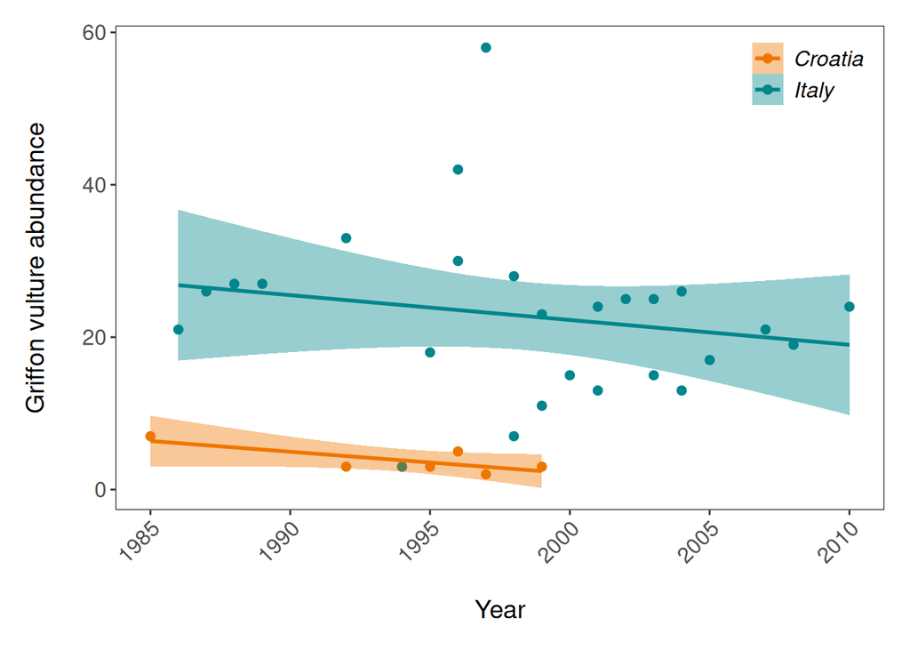

```r
vulture <- filter(LPI, Common.Name == "Griffon vulture / Eurasian griffon")
vultureITCR <- filter(vulture, Country.list == c("Croatia", "Italy"))

(vulture_scatter <- ggplot(vultureITCR, aes(x = year, y = abundance, colour = Country.list)) +
    geom_point(size = 2) +                                              # Changing point size
    geom_smooth(method = lm, aes(fill = Country.list)) +                # Adding a linear model fit and colour-coding by country
    scale_fill_manual(values = c("#EE7600", "#00868B")) +               # Adding custom colours
    scale_colour_manual(values = c("#EE7600", "#00868B"),               # Adding custom colours
                        labels = c("Croatia", "Italy")) +               # Adding labels for the legend
    ylab("Griffon vulture abundance\n") +
    xlab("\nYear")  +
        theme_bw() +
    theme(axis.text.x = element_text(size = 12, angle = 45, vjust = 1, hjust = 1),       # making the years at a bit of an angle
          axis.text.y = element_text(size = 12),
          axis.title.x = element_text(size = 14, face = "plain"),
          axis.title.y = element_text(size = 14, face = "plain"),
          panel.grid.major.x = element_blank(),                                # Removing the background grid lines
          panel.grid.minor.x = element_blank(),
          panel.grid.minor.y = element_blank(),
          panel.grid.major.y = element_blank(),
          plot.margin = unit(c(0.5, 0.5, 0.5, 0.5), units = , "cm"),           # Adding a 0.5cm margin around the plot
          legend.text = element_text(size = 12, face = "italic"),              # Setting the font for the legend text
          legend.title = element_blank(),                                      # Removing the legend title
          legend.position = 'inside',
          legend.position.inside = c(0.9, 0.9)))               # Setting the position for the legend - 0 is left/bottom, 1 is top/right
```

Here we are using the `theme_bw()` theme but we are making lots of modifications to it. When we need to make lots of graphs, e.g. all the graphs for a given research project, we would ideally like to format them in a consistent way - same font size, same layout of the graph panel. That means that we will be repeating many lines of code, but instead of doing that, we can take all the changes we want to make to the `ggplot2` theme and combine them into a function of our own! As a reminder, to start writing a function, you first assign it to an object. Since we are making a personalised theme for `ggplot2`, here I’ve called my function `theme.my.own`. To tell R that you are writing a function, you use `function()` and then the commands that you want your function to include go between the `{}`.

```r
theme.my.own <- function(){
  theme_bw()+
  theme(axis.text.x = element_text(size = 12, angle = 45, vjust = 1, hjust = 1),
        axis.text.y = element_text(size = 12),
        axis.title.x = element_text(size = 14, face = "plain"),
        axis.title.y = element_text(size = 14, face = "plain"),
        panel.grid.major.x = element_blank(),
        panel.grid.minor.x = element_blank(),
        panel.grid.minor.y = element_blank(),
        panel.grid.major.y = element_blank(),
        plot.margin = unit(c(0.5, 0.5, 0.5, 0.5), units = , "cm"),
        plot.title = element_text(size = 20, vjust = 1, hjust = 0.5),
        legend.text = element_text(size = 12, face = "italic"),
        legend.title = element_blank(),
        legend.position = c(0.9, 0.9))
}
```

Now we can make the same plot, but this time instead of all the code, we can just add + theme.my.own().

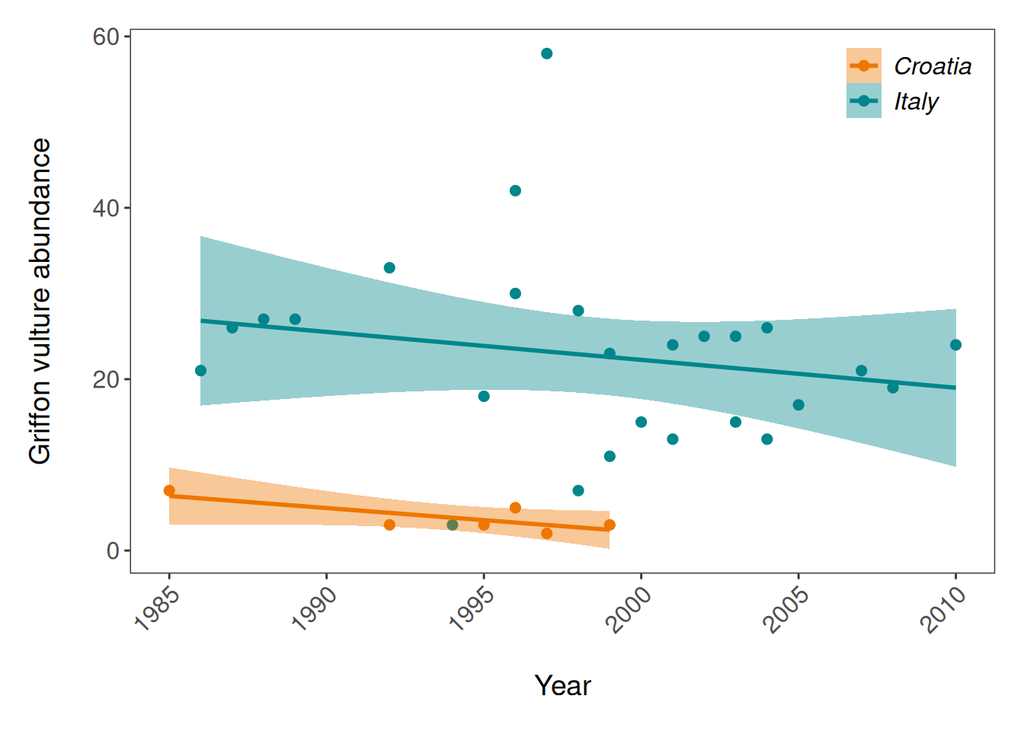

```r
p <- vulture_scatter <- ggplot(vultureITCR, aes (x = year, y = abundance, colour = Country.list)) +
    geom_point(size = 2) +
    geom_smooth(method = lm, aes(fill = Country.list)) +
    theme.my.own() +                                                    # Adding our new theme!
    scale_fill_manual(values = c("#EE7600", "#00868B")) +
    scale_colour_manual(values = c("#EE7600", "#00868B"),
                        labels = c("Croatia", "Italy")) +
    ylab("Griffon vulture abundance\n") +
    xlab("\nYear")
p
```

Let’s make more plots, again using our customised theme.

Filter the data to include only UK populations.

```r
LPI.UK <- filter(LPI, Country.list == "United Kingdom")

# Pick 4 species and make scatterplots with linear model fits that show how the population has varied through time
# Careful with the spelling of the names, it needs to match the names of the species in the LPI.UK dataframe

house.sparrow <- filter(LPI.UK, Common.Name == "House sparrow")
great.tit <- filter(LPI.UK, Common.Name == "Great tit")
corn.bunting <- filter(LPI.UK, Common.Name == "Corn bunting")
reed.bunting <- filter(LPI.UK, Common.Name == "Reed bunting")
meadow.pipit <- filter(LPI.UK, Common.Name == "Meadow pipit")
```

Making the plots:

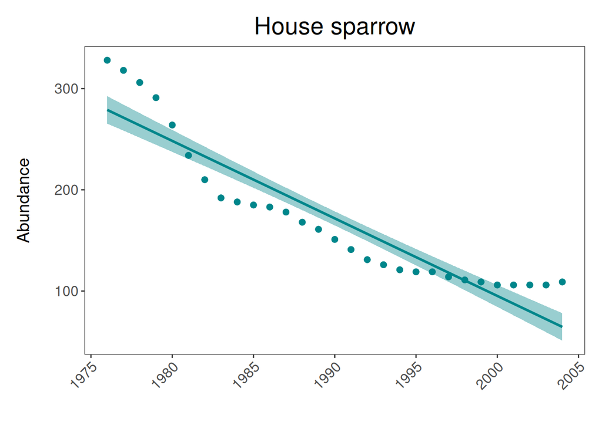

```r
(house.sparrow_scatter <- ggplot(house.sparrow, aes (x = year, y = abundance)) +
    geom_point(size = 2, colour = "#00868B") +
    geom_smooth(method = lm, colour = "#00868B", fill = "#00868B") +
    theme.my.own() +
    labs(y = "Abundance\n", x = "", title = "House sparrow"))
```

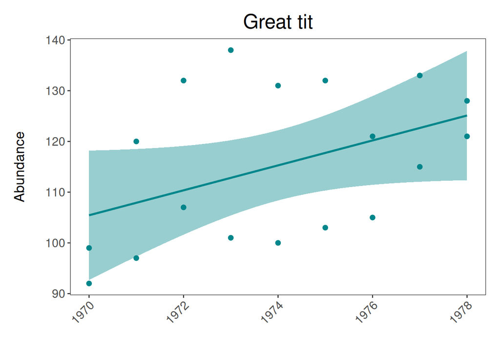

```r
(great.tit_scatter <- ggplot(great.tit, aes (x = year, y = abundance)) +
    geom_point(size = 2, colour = "#00868B") +
    geom_smooth(method = lm, colour = "#00868B", fill = "#00868B") +
    theme.my.own() +
    labs(y = "Abundance\n", x = "", title = "Great tit"))
```

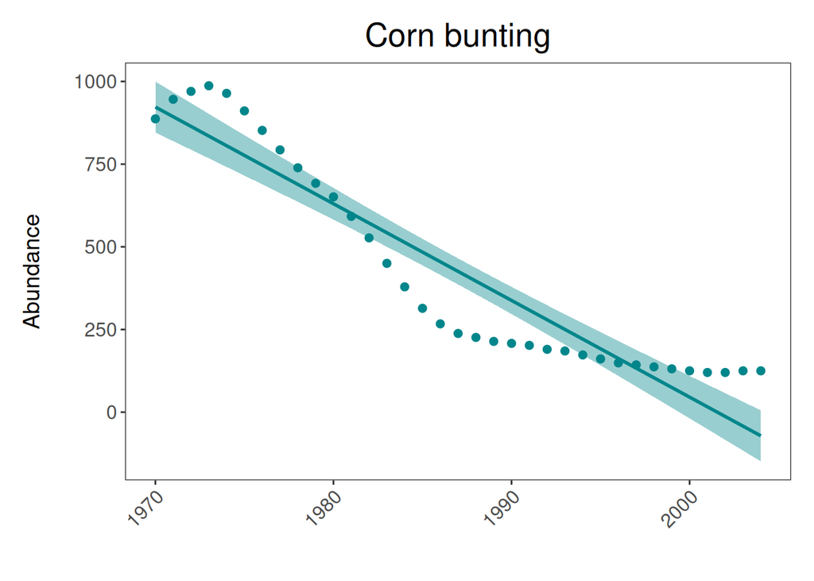

```r
(corn.bunting_scatter <- ggplot(corn.bunting, aes (x = year, y = abundance)) +
    geom_point(size = 2, colour = "#00868B") +
    geom_smooth(method = lm, colour = "#00868B", fill = "#00868B") +
    theme.my.own() +
    labs(y = "Abundance\n", x = "", title = "Corn bunting"))
```

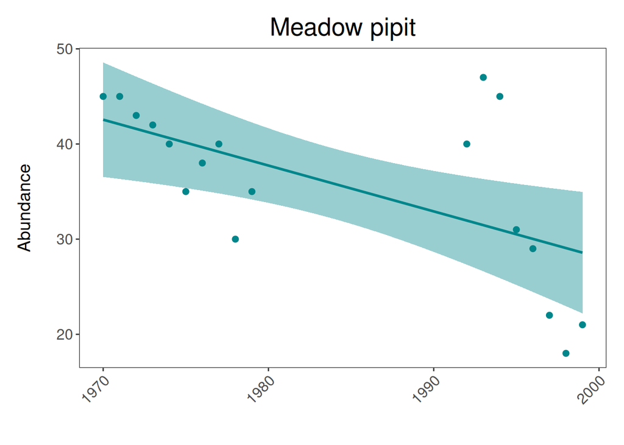

```r
(meadow.pipit_scatter <- ggplot(meadow.pipit, aes (x = year, y = abundance)) +
    geom_point(size = 2, colour = "#00868B") +
    geom_smooth(method = lm, colour = "#00868B", fill = "#00868B") +
    theme.my.own() +
    labs(y = "Abundance\n", x = "", title = "Meadow pipit"))
```

Now arrange all 4 plots in a panel using the gridExtra package and save the file

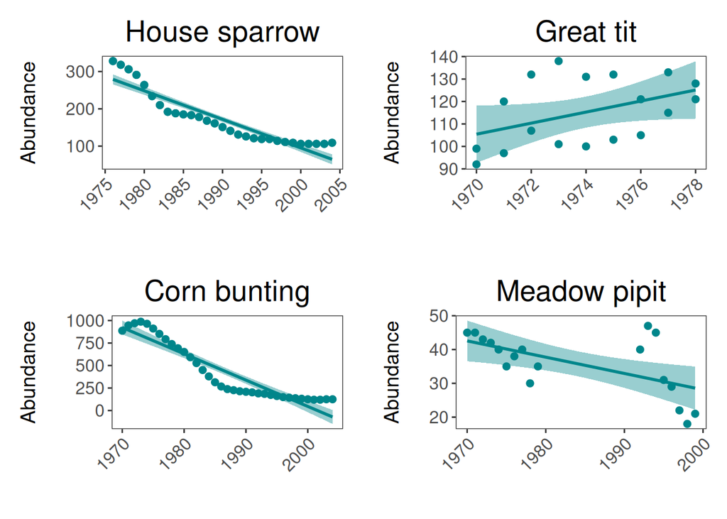

```r
panel <- grid.arrange(house.sparrow_scatter, great.tit_scatter, corn.bunting_scatter, meadow.pipit_scatter, ncol = 2)
```

```r
ggsave(panel, file = "Pop_trend_panel.png", width = 10, height = 8)
dev.off() # to close the image
```

That wasn’t too bad, but you are still repeating lots of code, and here you have only 4 graphs to make - what if you had to make a graph like this for every species in the LPI.UK dataset? That would mean repeating the same code over 200 times. That will be very time consumming, and it’s very easy to make mistakes when you are monotonously copying and pasting for hours.

You might be noticing a pattern in the above ggplot() commands - for every species, we want R to make the same type of graph. We can tell R to do exactly that using a loop!

First we need to make a list of species - we will tell R to make a graph for every item in our list:

```r
Sp_list <- list(house.sparrow, great.tit, corn.bunting, meadow.pipit)
```

Writing the loop:

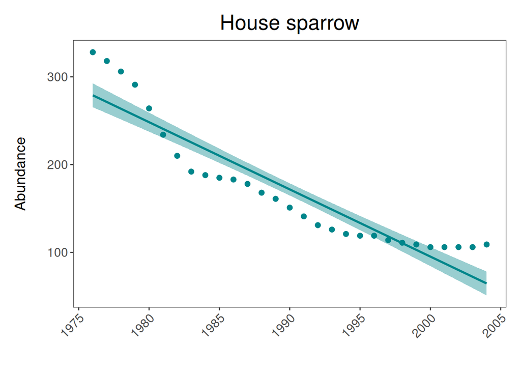

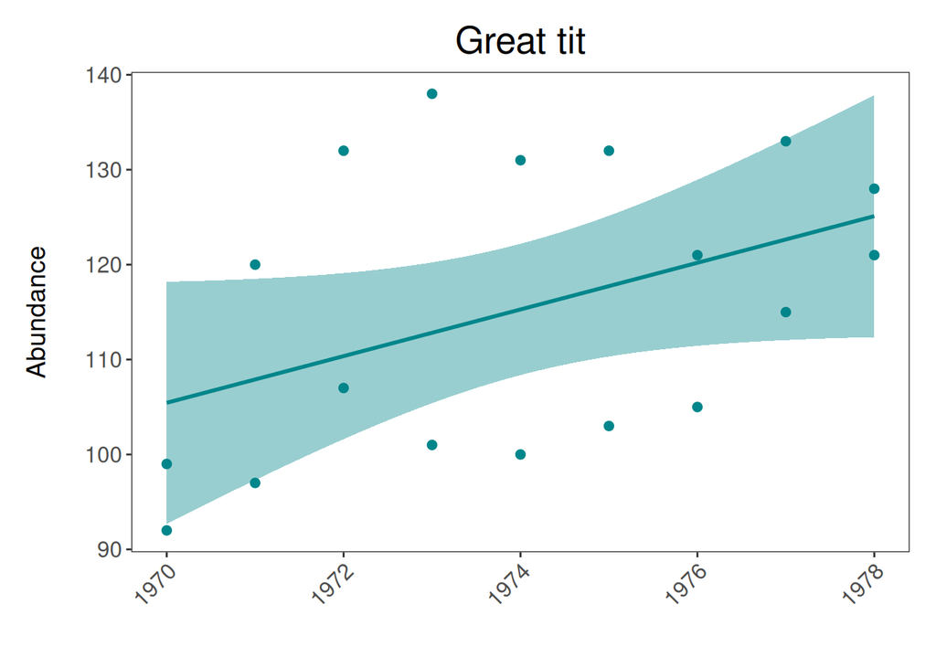

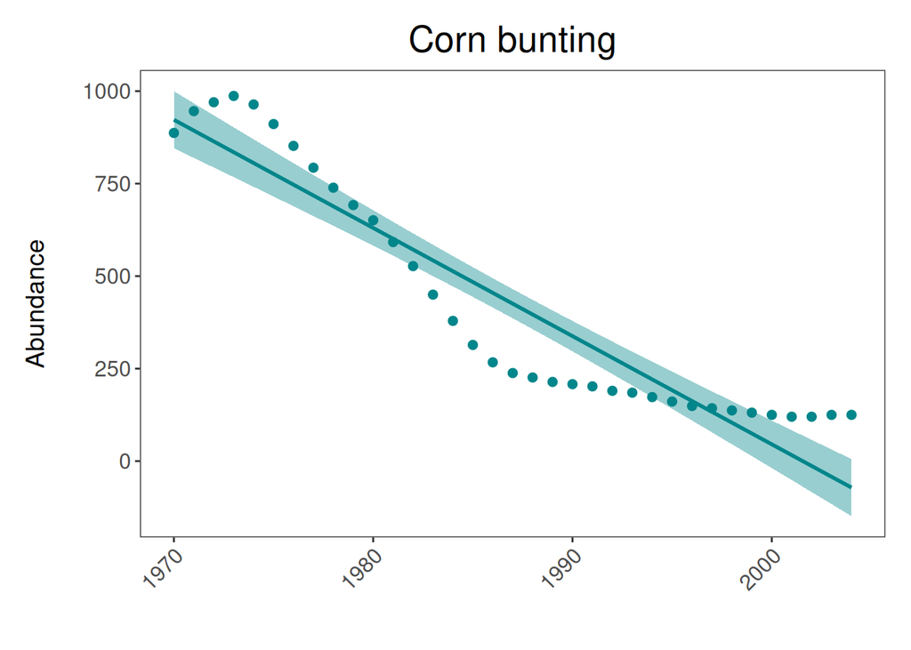

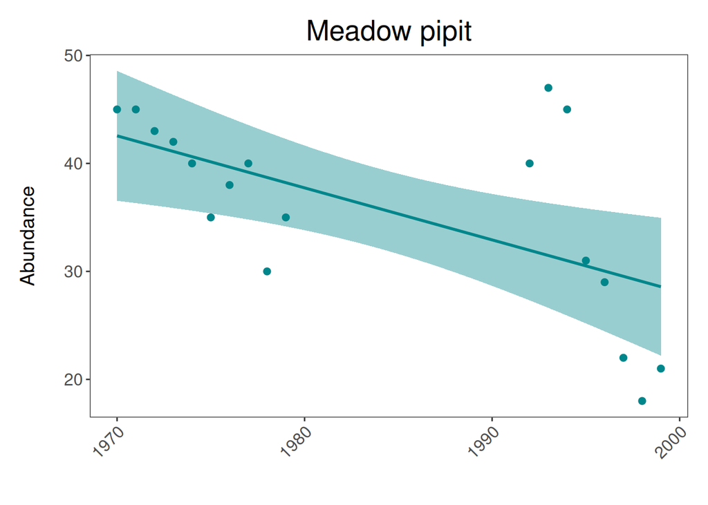

```r
for (i in 1:length(Sp_list)) {                                    # For every item along the length of Sp_list we want R to perform the following functions
  data <- as.data.frame(Sp_list[i])                               # Create a dataframe for each species
  sp.name <- unique(data$Common.Name)                             # Create an object that holds the species name, so that we can title each graph
  plot <- ggplot(data, aes (x = year, y = abundance)) +               # Make the plots and add our customised theme
    geom_point(size = 2, colour = "#00868B") +
    geom_smooth(method = lm, colour = "#00868B", fill = "#00868B") +
    theme.my.own() +
    labs(y = "Abundance\n", x = "", title = sp.name)

  ggsave(plot, file = paste(sp.name, ".pdf", sep = ''), scale = 2)       # save plots as .pdf, you can change it to .png if you prefer that

  print(plot)                                                      # print plots to screen
}
```